# Do a numerical vs categorical bivariate analysis on the penguins dataset

- Choose one of the categorical columns: species, island or sex
- use .groupby().mean() to look at the means of the numerical columns. Does it look like there is a difference between categories?
- Use the seaborn barplot to plot the mean and confidence. Create this plot for each of the numerical columns (bill_length_mm, bill_depth_mm, flipper_length_mm, body_mass_g)
- For each of the plots, write a conclusion; Is there a statistically significant difference for this numerical column for each category?
- Optional; repeat this process for the two other categorical columns

```python
import seaborn as sns
from matplotlib import pyplot as plt
```

```python
penguins = sns.load_dataset("penguins")
penguins.head()
```

|  | species | island | bill_length_mm | bill_depth_mm | flipper_length_mm | body_mass_g | sex |
| --- | --- | --- | --- | --- | --- | --- | --- |
| 0 | Adelie | Torgersen | 39.1 | 18.7 | 181.0 | 3750.0 | Male |
| 1 | Adelie | Torgersen | 39.5 | 17.4 | 186.0 | 3800.0 | Female |
| 2 | Adelie | Torgersen | 40.3 | 18.0 | 195.0 | 3250.0 | Female |
| 3 | Adelie | Torgersen | NaN | NaN | NaN | NaN | NaN |
| 4 | Adelie | Torgersen | 36.7 | 19.3 | 193.0 | 3450.0 | Female |

## Research done on: Island

### Verschil tussen eilanden

In de tabel hieronder is te zien dat het verschil tussen lengtes niet heel groot zijn, de depth idem. Bij flipper lengte is een verschil van ongeveer 20mm tussen Dream en Torgersen vergeleken met Biscoe. Ook is te zien dat de body mass op Biscoe 1000g hoger is.

```python
penguins.groupby("island").mean()
```

| island | bill_length_mm | bill_depth_mm | flipper_length_mm | body_mass_g |
| --- | --- | --- | --- | --- |
| Biscoe | 45.257485 | 15.874850 | 209.706587 | 4716.017964 |
| Dream | 44.167742 | 18.344355 | 193.072581 | 3712.903226 |
| Torgersen | 38.950980 | 18.429412 | 191.196078 | 3706.372549 |

```
<BarContainer object of 344 artists>
```

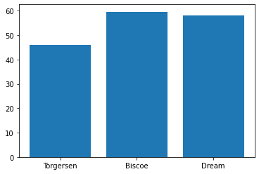

```python
plt.bar(penguins.island, penguins.bill_length_mm)
```

Hier is te zien dat torgersen een relatief lagere lengte heeft in bill length

```
<BarContainer object of 344 artists>
```

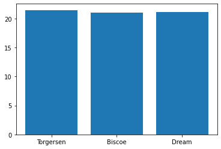

```python
plt.bar(penguins.island, penguins.bill_depth_mm)
```

```
<BarContainer object of 344 artists>
```

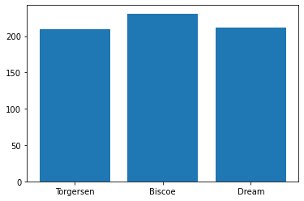

```python
plt.bar(penguins.island, penguins.flipper_length_mm)
```

Hier is te zien dat de penguins op biscoe iets langere flippers hebben

```
<BarContainer object of 344 artists>
```

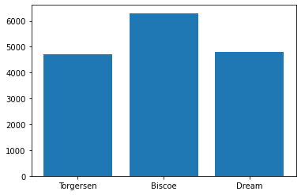

```python
plt.bar(penguins.island, penguins.body_mass_g)
```

Hier is te zien dat de penguins op Biscoe gemiddeld 1kg zwaarder zijn dan op andere eilanden